# Pnad Contínua

Autor

Eliana Cardoso Gonçalves

Data de Publicação

02/09/2025

## 1 Introdução

A Pesquisa Nacional por Amostra de Domicílios Contínua (PNAD Contínua) investiga, trimestralmente, um conjunto de informações conjunturais sobre as tendências e flutuações da força de trabalho e, de forma anual, temas estruturais relevantes para a compreensão da realidade brasileira. Por se tratar de uma amostra, os dados não estão prontos para uso imediato, pois a PNAD Contínua utiliza uma amostragem probabilística complexa, realizada em várias etapas. Cada indivíduo possui um peso amostral, que indica quantas pessoas na população ele representa, além de estar associado a estratos e conglomerados.

Por isso, este relatório tem como objetivo facilitar a extração dos dados e orientar sobre como realizar análises corretas, garantindo que os resultados sejam representativos da população brasileira.

## 2 Extração

O IBGE criou um pacote no R chamado `PNADcIBGE`, que permite acessar todos os microdados da PNAD Contínua de forma rápida e fácil.

```r
# Instalação dos pacotes (caso ainda não estejam instalados)
#install.packages("PNADcIBGE")
# Carregando os pacotes
library(PNADcIBGE)
```

Depois de instalado e carregado o pacote, podemos chamar a função get_pnadc, que baixa os microdados da PNAD Contínua diretamente para o R.

```r
variaveis <- c("VD4009", "VD4012", "V4013", "V2009", "VD4037",
  "VD4016", "VD4017", "VD4019", "VD4020",
  "VD3004", "V2010", "V2007", "V4010"




)

pnad_cont <- get_pnadc(year = 2025, quarter = 2,vars=variaveis, design = TRUE)
```

A função get_pnadc permite extrair os dados selecionando o ano e o trimestre de interesse. É possível extrair todas as variáveis, deixando de fora o argumento vars, ou selecionar apenas as variáveis desejadas, especificando-as nesse parâmetro.

Se o argumento design não for utilizado, as análises realizadas — como médias, proporções e totais — serão apenas simples médias da amostra. Isso pode gerar resultados enviesados, ou seja, que não representam corretamente a população brasileira.

O design amostral é o objeto criado quando definimos design = TRUE. Ele faz com que o R compreenda como a amostra foi coletada, incorporando as informações necessárias para análises corretas. Entre essas informações estão os pesos amostrais, que indicam quantas pessoas cada indivíduo da amostra representa; a estratificação, que garante a representatividade de diferentes regiões, sexo, idade e outros recortes; e os conglomerados, que agrupam algumas unidades, como domicílios, e precisam ser considerados nas estimativas.

## 3 Análise dos dados

Antes de iniciar as análises, também iremos baixar e carregar o pacote survey no R. Esse pacote é fundamental para trabalhar com dados de pesquisas amostrais complexas, como a PNAD Contínua. Ele permite realizar análises que consideram pesos amostrais, estratificação e conglomerados, garantindo que médias, proporções, totais e intervalos de confiança sejam representativos da população.

Quando combinamos o pacote PNADcIBGE com o survey, é possível criar um objeto de desenho amostral (survey.design) usando o argumento design = TRUE na função get_pnadc. Dessa forma, todas as análises subsequentes no R levam em conta a complexidade da amostra, evitando resultados enviesados.

Além do pacote survey, existe também o pacote srvyr, que facilita o trabalho com pesquisas amostrais complexas no R. Enquanto o survey utiliza uma sintaxe própria, o srvyr integra os recursos do survey com a gramática do dplyr, tornando a escrita do código mais simples e intuitiva. Dessa forma, é possível aplicar funções como summarise, mutate e group_by diretamente em objetos de desenho amostral, sem perder a correção estatística garantida pelo uso dos pesos, estratos e conglomerados.

```r
#install.packages("survey")
#install.packages("srvyr")


library(survey)
library(srvyr)
```

Suponhamos que desejamos calcular a média salarial no Brasil considerando o gênero (mulheres e homens) e a raça.

O primeiro passo é converter o objeto de dados, que normalmente é um data.frame ou tibble contendo as informações da PNAD Contínua, em um objeto de desenho amostral compatível com o pacote srvyr. Isso é importante para que todos os cálculos considerem os pesos, estratos e conglomerados da pesquisa, garantindo que os resultados sejam representativos da população brasileira.

```r
# Converter os dados para desenho amostral com srvyr

pnad_cont <- as_survey(pnad_cont)
```

O código abaixo calcula a média salarial por sexo (V2007) e raca (V2010) a partir do objeto pnad_cont, que já está convertido em desenho amostral com o pacote srvyr:

Lembrando que o dicionário das variáveis da PNAD Contínua está disponível no site do IBGE. Nele é possível consultar o significado de cada código, as categorias das variáveis e informações detalhadas sobre como foram coletadas. Isso é essencial para interpretar corretamente os microdados e garantir que as análises sejam precisas.

Site do IBGE: https://www.ibge.gov.br/estatisticas/sociais/trabalho/9173-pnad-continua.html

Variáveis contínuas → survey_mean() calcula a média ponderada.

```r
salario <- pnad_cont %>%
    filter(!is.na(VD4020)) %>%    # Remove observações sem renda
    group_by( V2007, V2010) %>%      # Agrupa por raca e sexo
    summarise(salario_medio = survey_mean(VD4020, na.rm = TRUE), .groups = "drop")

salario
```

| V2007 | V2010 | salario_medio | salario_medio_se |
| --- | --- | --- | --- |
| Homem | Branca | 5045.085 | 65.24935 |
| Homem | Preta | 2849.569 | 56.03085 |
| Homem | Amarela | 7092.667 | 718.69508 |
| Homem | Parda | 2945.785 | 30.98851 |
| Homem | Indígena | 2426.550 | 147.85465 |
| Homem | Ignorado | 5343.083 | 1640.90475 |
| Mulher | Branca | 3813.793 | 43.57907 |
| Mulher | Preta | 2305.732 | 85.73552 |
| Mulher | Amarela | 4651.274 | 306.32752 |
| Mulher | Parda | 2337.797 | 18.94729 |
| Mulher | Indígena | 2295.761 | 270.27918 |
| Mulher | Ignorado | 2442.235 | 452.03492 |

Depois de calcular a média salarial por sexo e raca, você já pode visualizar os resultados ou fazer qualquer tipo de análise que desejar. Por exemplo:

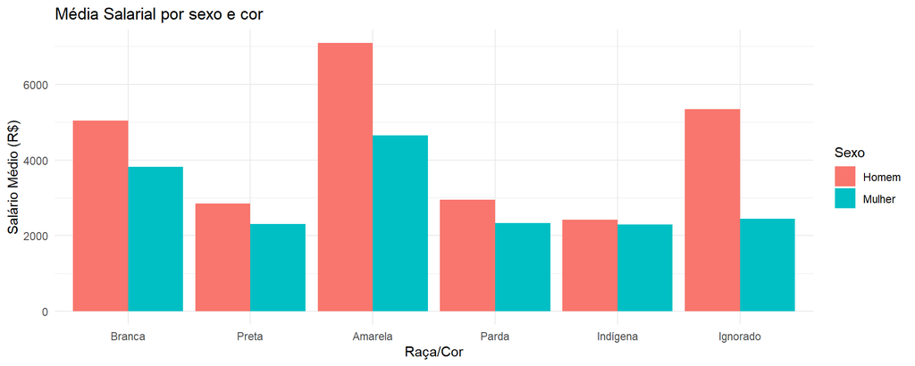

```r
library(ggplot2)
library(dplyr)

# Supondo que 'salario' já está criado como antes

# Criar um gráfico de barras comparando média salarial por raça e sexo
ggplot(salario, aes(x = factor(V2010), y = salario_medio, fill = factor(V2007))) +
  geom_col(position = "dodge") +
  labs(
    title = "Média Salarial por sexo e cor",
    x = "Raça/Cor",
    y = "Salário Médio (R$)",
    fill = "Sexo"
  ) +
  theme_minimal()
```

```r
escolaridade_sexo  = pnad_cont %>%   # Remove observações sem renda
    group_by( V2007, VD3004) %>%      # Agrupa por raca e sexo
    summarise(contagem = survey_total( na.rm = TRUE), .groups = "drop")
escolaridade_sexo
```

| V2007 | VD3004 | contagem | contagem_se |
| --- | --- | --- | --- |
| Homem | Sem instrução e menos de 1 ano de estudo | 6868057 | 6.507980e+04 |
| Homem | Fundamental incompleto ou equivalente | 31100944 | 1.462333e+05 |
| Homem | Fundamental completo ou equivalente | 7162884 | 8.429899e+04 |
| Homem | Médio incompleto ou equivalente | 7271282 | 7.473595e+04 |
| Homem | Médio completo ou equivalente | 27228323 | 1.494023e+05 |
| Homem | Superior incompleto ou equivalente | 4372485 | 6.873988e+04 |
| Homem | Superior completo | 13216327 | 1.706795e+05 |
| Homem | NA | 6490377 | 9.200000e-05 |
| Mulher | Sem instrução e menos de 1 ano de estudo | 6815154 | 6.932124e+04 |
| Mulher | Fundamental incompleto ou equivalente | 29875670 | 1.250929e+05 |
| Mulher | Fundamental completo ou equivalente | 7071248 | 7.762621e+04 |
| Mulher | Médio incompleto ou equivalente | 6735001 | 6.902431e+04 |
| Mulher | Médio completo ou equivalente | 29027614 | 1.477144e+05 |
| Mulher | Superior incompleto ou equivalente | 5179598 | 6.392422e+04 |
| Mulher | Superior completo | 18117450 | 1.901853e+05 |
| Mulher | NA | 6193246 | 1.123000e-04 |

E o gráfico:

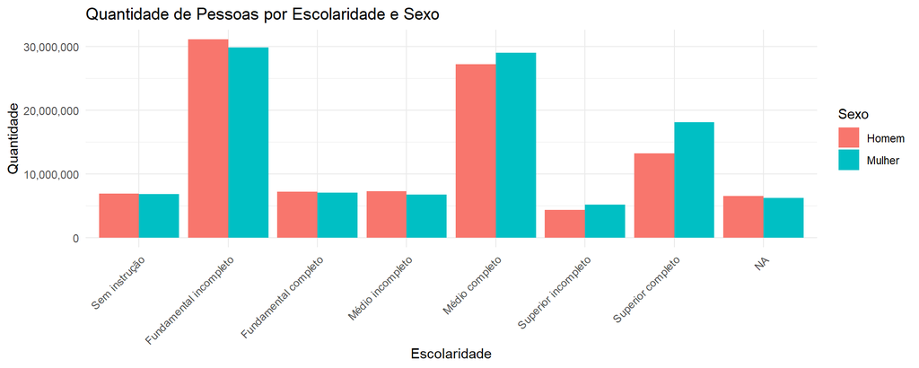

```r
escolaridade_sexo <- escolaridade_sexo %>%
  mutate(
    escola = factor(VD3004,
                    levels = c(
                      "Sem instrução e menos de 1 ano de estudo",
                      "Fundamental incompleto ou equivalente",
                      "Fundamental completo ou equivalente",
                      "Médio incompleto ou equivalente",
                      "Médio completo ou equivalente",
                      "Superior incompleto ou equivalente",
                      "Superior completo"
                    ),
                    labels = c(
                      "Sem instrução",
                      "Fundamental incompleto",
                      "Fundamental completo",
                      "Médio incompleto",
                      "Médio completo",
                      "Superior incompleto",
                      "Superior completo"
                    ))
  )


# Gráfico final
ggplot(escolaridade_sexo, aes(x = escola, y = contagem, fill = V2007)) +
  geom_col(position = "dodge") +
  labs(
    title = "Quantidade de Pessoas por Escolaridade e Sexo",
    x = "Escolaridade",
    y = "Quantidade",
    fill = "Sexo"
  ) +
  theme_minimal() +
  scale_y_continuous(labels = scales::comma) +
  theme(axis.text.x = element_text(angle = 45, hjust = 1))
```